# Multi-species occupancy models in R: estimating the number of undetected species

Multi-species occupancy models in R: estimating the number of undetected species James E Paterson 2025-05-10

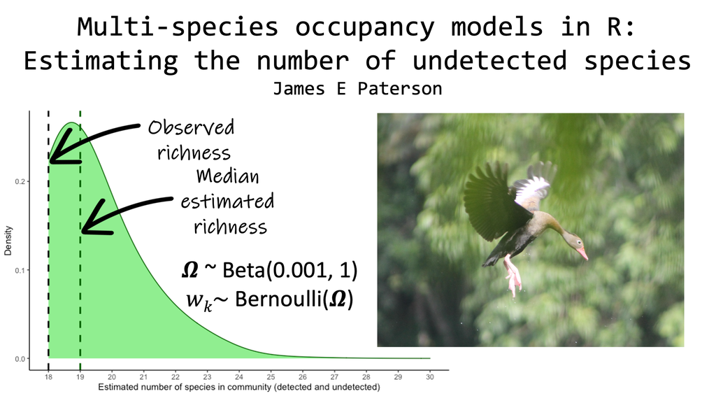

In this tutorial, I cover:

Fitting multi-species single-season occupancy models that estimate the number of undetected species using `jagsUI` in R.

The code and sample data from this tutorial are available on my [occupancyworkshop GitHub repo](https://github.com/jamesepaterson/occupancyworkshop).

Occupancy models use repeated visits to estimate the probability of sites being occupied by species using a hierarchical modelling framework, and can treat species similar to random effects. In my previous tutorial, [we built multi-species occupancy models with covariates and estimated species richness at each site](https://jamesepaterson.weebly.com/blog/multi-species-occupancy-models-in-r-covariates-and-estimating-species-richness). Here, we extend that to:

1. Augment data with undetected species.
2. Estimate the species richness at different sites, including species that were never detected in the study.

## Augmenting data in Multi-Species Occupancy Models (MSOMs)

In the previous tutorial, we estimated how many species are at a site using the latent state matrix (z) to sum the number of species. However, it’s possible that there were additional species present at some sites that were never detected in any survey at any site. How can we estimate how many, and include those undetected species into species richness estimates per site and for the community?

In the model, we:

- augment our capture history data with species that have 0 detections. The number of undetected species to add depends on the system. For example, you may know the exact number of species (or the upper boundary) that occur in your study, or not.
- add a parameter ($\Omega$) for the probability that a species is part of the community.
- estimate a binary identifier (*w*$_{k}$) that each species *k* is part of the community, using a Bernoulli draw based on $\Omega$.
- define the community level hyperpriors for $\Omega$. How informative the hyperprior is depends on the study system. Link (2013) recommended a Beta(0.001, 1) prior, which favours a low $\Omega$ and therefore a total size of the community, *N*, closer to the observed number of species. This restriction means that community richness estimates becomes less likely as they start to exceed the number of species observed and approach the total number of detected and undetected species in the augmented data (i.e., the maximum N is the total number of species that are observed plus the number of augmented species, when $\Omega$ = 1).

We use the previous multi-species occupancy model with covariates as our starting point, and add the additional parameters. For a brief introduction to this approach, I suggest reading [Devarajan et al. 2020’s review of MSOMs](https://nsojournals.onlinelibrary.wiley.com/doi/full/10.1111/ecog.04957).

Mathematically:

Model:
$$\begin{align*}
logit(\psi_{i,k}) \sim \beta_{0,k} + \beta_{forest,k}*forest_i + \beta_{agri,k}*agri_i \\
z_{i, k} \sim {\sf Bern}(\psi_{i, k}*w_k)
\\
\end{align*}$$
Species priors:
$$\begin{align*}
\\
\beta_{0, k} \sim {\sf Normal}(\mu_{intercept}, 1/\sigma_{intercept}^2)\\
\beta_{forest, k} \sim {\sf Normal}(\mu_{forest}, 1/\sigma_{forest}^2)\\
\beta_{agri, k} \sim {\sf Normal}(\mu_{agri}, 1/\sigma_{agri}^2)\\
w_k \sim {\sf Bern}(\Omega)\\
\end{align*}$$
Community hyperpriors:
$$\begin{align*}
\overline{\beta_0} \sim {\sf Beta}(\alpha = 1,\beta = 1)\\
\mu_{0} \sim logit(\overline{\beta_0})\\
\sigma_{0} \sim {\sf Uniform}(min = 0, max = 5)\\
\\
\mu_{forest} \sim {\sf Uniform}(min = -5, max = 5)\\
\sigma_{forest} \sim {\sf Uniform}(min = 0, max = 5)\\
\\
\mu_{agri} \sim {\sf Uniform}(min = -5, max = 5)\\
\sigma_{agri} \sim {\sf Uniform}(min = 0, max = 5)\\
\\
\\\Omega \sim {\sf Beta}(\alpha = 0.001, \beta = 1)\\
\end{align*}$$

## Estimating the number of species at a site

The success of using data augmentation for estimating species richness varies with the specific data, and is more challenging when detection probabilities are very low.

I caution you to think critically about the estimate you get in your own analyses and whether the priors for $\Omega$ are appropriate. Previous work has found that the community size estimates can be largely inaccurate for some cases (e.g., massively overestimating the community species richness). However, this can still inform you whether the community has been adequately sampled (estimated number of species similar to what was detected) in the study or not (estimated number of species much larger than what was detected).

## Loading and organizing data

```r
# Load libraries
library(dplyr) # for data organization
library(ggplot2) # for plotting

# Load arrary of community detection history
# 100 x rows (sites) x 18 columns (species) with values for the number of detections in 10 surveys
y <- read.csv("community_detection_3visits.csv") %>%
  dplyr::select(-X)

# Convert detection history to numeric
z <- (y > 0)*1  # *1 converts to numeric, keeps matrix
z[z == 0] <- NA

# Load sitecov, effort, observers,
site.cov <- read.csv(file = "site_cov.csv") %>%
  dplyr::select(-X)
```

## Fit covariate model with augmented data and omega

```r
library(jagsUI)

naug <- 50 - ncol(y) # 18 observed species, we'll augment the data with an additional 32 species for a total of 50

# Updated y; matrix of detection histories that includes detected and non-detected species
yaug <- cbind(y, matrix(0, nrow(y), naug))

# Initial w vector (1 for detected species, NA for augmented undetected species)
w <- c(rep(1, ncol(y)), rep(NA, naug))

# Initial values for latent state occupancy (1 for detected, otherwise NA)
z <- (yaug > 0)*1
z[z == 0] <- NA

# Package data for jags
msom_augmented_jags_data <- list(y = yaug,# y = the detection history matrix
                                  nSobs = ncol(yaug), # The total number of species observed + augmented
                                  nSites = nrow(yaug), # The total number of sites
                                  nOcc = 3, # Each site visited 10 times
                                  z = z, # z = latent state occupancy
                                  w = w, # w = binary identifier of whether a species is part of the community
                                   # Covariates (already standardized)
                                  forest = site.cov$forest,
                                  agri = site.cov$agri)

# Hierarchical model
# For fitting basic multi-species occupancy models, we can think of the components as
# 1. an ecological model
# 2. an observation model
# 3. Priors that describe species level variation in psi and p
# 4. hyperpriors that describe parameters for the community
# Create a temporary file "msom_augmented"
# Identify filepath of model file
msom_augmented <- tempfile()

# Write model to file
writeLines("
model{
  for(k in 1:nSobs){  # Loop through species, including augmented data
  w[k] ~ dbern(omega)
    # Likelihood
    for(i in 1:nSites) {
       # Ecological model
      logit(psi[i, k]) <- b0[k] + bforest[k]*forest[i] + bagri[k]*agri[i]
       z[i, k] ~ dbern(psi[i, k]*w[k]) # Addition of w[k] qualifying whether species are at a site
       # Observation model
       y[i, k] ~ dbin(p[k] * z[i, k], nOcc)
    }

    # Priors (species level)
    b0[k] ~ dnorm(mu.b0, tau.b0)
    # mu.eta[k] <- mu.lp + rho * sd.lp/sd.b0 *
    #     (b0[k] - mu.b0)
    # lp[k] ~ dnorm(mu.eta[k], tau.eta)
    lp[k] ~ dnorm(mu.lp, tau.lp)
    p[k] <- ilogit(lp[k])

    bforest[k] ~ dnorm(mu.forest, tau.forest)
    bagri[k] ~ dnorm(mu.agri, tau.agri)

  }

  # Hyperpriors (community level)
  omega ~ dbeta(0.001, 1) # Link (2013) suggested strong prior Beta(0.001, 1)

  b0.mean ~ dbeta(1, 1)
  mu.b0 <- logit(b0.mean)
  sd.b0 ~ dunif(0, 5)
  tau.b0 <- 1/sd.b0^2

  mu.forest ~ dunif(-5, 5)
  sd.forest ~ dunif(0, 5)
  tau.forest <- 1/sd.forest^2

  mu.agri ~ dunif(-5, 5)
  sd.agri ~ dunif(0, 5)
  tau.agri <- 1/sd.agri^2

  p.mean ~ dbeta(1, 1)
  mu.lp <- logit(p.mean)
  sd.lp ~ dunif(0, 5)
  tau.lp <- 1/sd.lp^2

  # Derived species richness
  N <- sum(w)
}
", con = msom_augmented)

# Parameters monitored (greatly reducing to focus on omega, N, z, w)
wanted <- c("omega", "N",
            "z", "w")

# Run model
msom_augmented_out <- jags(msom_augmented_jags_data,
                           NULL, wanted, msom_augmented,
                           n.chains = 3, n.iter = 25000,
                           n.burnin = 5000, n.thin = 5,
                           parallel = TRUE, DIC = FALSE)
```

```
##
## Processing function input.......
##
## Converted data.frame y to matrix
##
## Done.
##
## Beginning parallel processing using 3 cores. Console output will be suppressed.
##
## Parallel processing completed.
##
## Calculating statistics.......
##
## Done.
```

```r
# Summary
modelSummary <- summary(msom_augmented_out)
```

Now we examine the posterior distribution of $\Omega$ and the derived parameter, *N* to estimate how many species we likely missed.

```r
# Posterior distribution of Omega
modelSummary["omega",]
```

```
##         mean           sd         2.5%          25%          50%          75%
##   0.39059068   0.07784194   0.24919913   0.33625972   0.38741044   0.44122412
##        97.5%         Rhat        n.eff     overlap0            f
##   0.55230615   1.00626809 362.00000000   0.00000000   1.00000000
```

```r
# Posterior distribution of N
modelSummary["N",]
```

```
##       mean         sd       2.5%        25%        50%        75%      97.5%
##  19.883750   1.921209  18.000000  18.000000  19.000000  21.000000  25.000000
##       Rhat      n.eff   overlap0          f
##   1.031710 114.000000   0.000000   1.000000
```

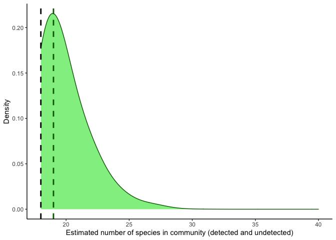

```r
# Plot distribution of N
ggplot(data = data.frame(N = msom_augmented_out$sims.list$N), aes(x = N)) +
  # geom_histogram(fill = "white", col = "black") +
  geom_density(col = "dark green", adjust = 4, fill = "light green") +
  geom_vline(aes(xintercept = median(msom_augmented_out$sims.list$N)),
            color = "dark green", linetype = "dashed", size = 1)+
  geom_vline(aes(xintercept = 18),
            color = "black", linetype = "dashed", size = 1)+
  scale_x_continuous(limits = c(18, 40))+
  labs(x = "Estimated number of species in community (detected and undetected)",
       y = "Density") +
  theme_classic()
```

The median estimate of $\Omega$ is 0.387. Recall that we had detections of 18 species, and augmented the data with an additional 32 species for a total of 50. Since: 50 * 0.387 = 19.371 and the median posterior distribution of *N* = 19, our estimate suggests that there was very few additional species (~1-2) present at sites that was not detected at any survey.

We can use the z matrix of latent occupancy state, similar to the previous tutorial, to estimate the number of species at each site. The predicted number of species at a site can now technically be higher than the total number of species we observed (18) because we augmented with additional unobserved species.

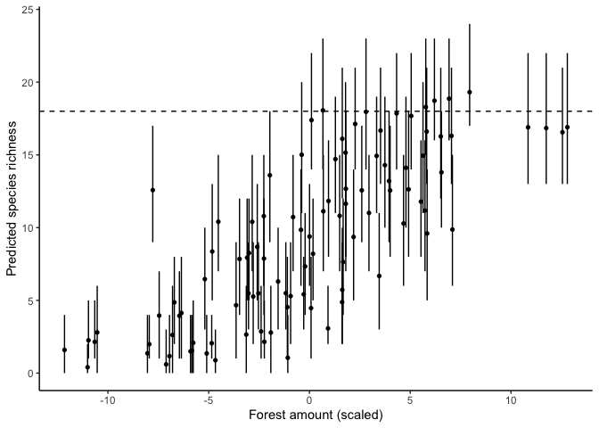

```r
# Species occupancy state at each site
z_results <- msom_augmented_out$sims.list$z

# Calculate average species richness per site
ndraws <- dim(z_results)[1] # Sample size (number of draws from posterior distribution)
richnessMatrix <- matrix(nrow = 100, ncol = ndraws) # Matrix to hold results

# For each draw from the posterior distribution
for(i in 1:ndraws){
  # Calculate the species richness by summing species
  # Each row is a site, each column is one draw
  richnessMatrix[,i] <- rowSums(z_results[i,,])
}

richnessDF <- richnessMatrix %>%
  as.data.frame(.) %>%
  # Calculate the average, SD, lower (2.5%) and upper (95.5%) of the distribution per site
  mutate(meanRichness = rowMeans(dplyr::select(., starts_with("V")), na.rm = TRUE),
         sdRichness = apply(X = richnessMatrix, MARGIN = 1, FUN = sd),
         lowerRichness = apply(X = richnessMatrix, MARGIN = 1,
                               FUN = quantile, probs = 0.025),
         upperRichness = apply(X = richnessMatrix, MARGIN = 1,
                               FUN = quantile, probs = 0.975),
         sites = as.character(1:100)) %>%
  # Join to the site dataframe to have the covariate
  left_join(., site.cov %>%
              mutate(sites = as.character(sites)),
            by = "sites") %>%
  # Limit the data frame to just the variables we need
  dplyr::select(sites, meanRichness, sdRichness,
                lowerRichness, upperRichness,
                forest, agri)

# Plot richness vs forest
# Horizontal line at total number of unique species observed (18)
ggplot(richnessDF, aes(x = forest, y = meanRichness)) +
  geom_point(pch = 16) +
  geom_errorbar(aes(ymin = lowerRichness, ymax = upperRichness), width = 0) +
  labs(y = "Predicted species richness", x = "Forest amount (scaled)") +
  geom_hline(aes(yintercept = 18), linetype = "dashed") +
  theme_classic()
```

In our plot of forest amount vs predicted species richness, we can see several sites predicted to have more than 18 species, the total number detected across the 100 sites.

## Summary

We extended our models to estimate how many species are in the study area (and at each study site) using data augmentation and additional parameters ($\Omega$ & *w*$_{k}$). This approach is useful, but can be tricky in applications where many species (e.g., >15%) are missed in a set of surveys. Both the prior selection for $\Omega$, and the number of species to augment with can strongly affect the inferences you make on missed species. In our example, the data strongly suggested there were very few (~1-2) additional species missed during the surveys.

Have suggestions for a tutorial you want on spatial ecology, mark-recapture models, occupancy models, or another related topic? Let me know!

## Further reading and references

1. [Multi-species occupancy models in R](https://jamesepaterson.weebly.com/blog/multi-species-occupancy-models-in-r).
2. [Multi-species occupancy models in R: covariates and estimating species richness](https://jamesepaterson.weebly.com/blog/multi-species-occupancy-models-in-r-covariates-and-estimating-species-richness)
3. [Devarajan et al. 2020. Multi-species occupancy models: review, roadmap, and recommendations review of MSOMs. Ecography 43(11): 1612-1624](https://nsojournals.onlinelibrary.wiley.com/doi/full/10.1111/ecog.04957)

Written by [James E Paterson](https://jamesepaterson.weebly.com/)